# Transcriptomal Changes in NPCs Following Exposure to Spinal Cord Injury

31 mars 2018

# 1 Executive Summary

# 2 Project Description

**Hypothesis:**

**Experimental setup & sequencing:**

**Data analysis:** Data was analysed using edgeR and limma packages, both available through [Bioconductor](https://www.bioconductor.org/) using R (version 3.4.4, *Someone to Lean On*). Two additional key packages used were ggplot2 and data.table.

# 3 Data Overview

**Table 1. Data set characteristics.**

| Characteristic | Value |
| --- | --- |
| Samples (n): | 19 |
| Groups (n): | 5 |
| Unique ENSEMBL IDs (n): | 32545 |

# 4 Data Pre-Processing

## 4.1 *Removing genes with low expression*

**Fig 1. Density of log-CPM values pre -and post filtering**

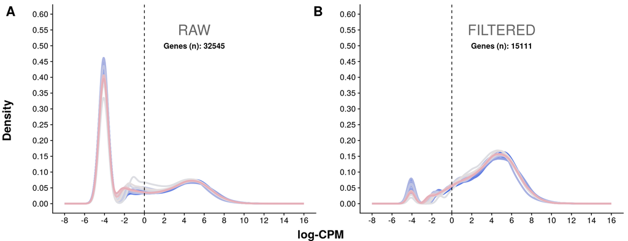

## 4.2 *Adjusting gene expression distributions*

**Fig 2. Distribution of log-CPM values pre -and post normalization**

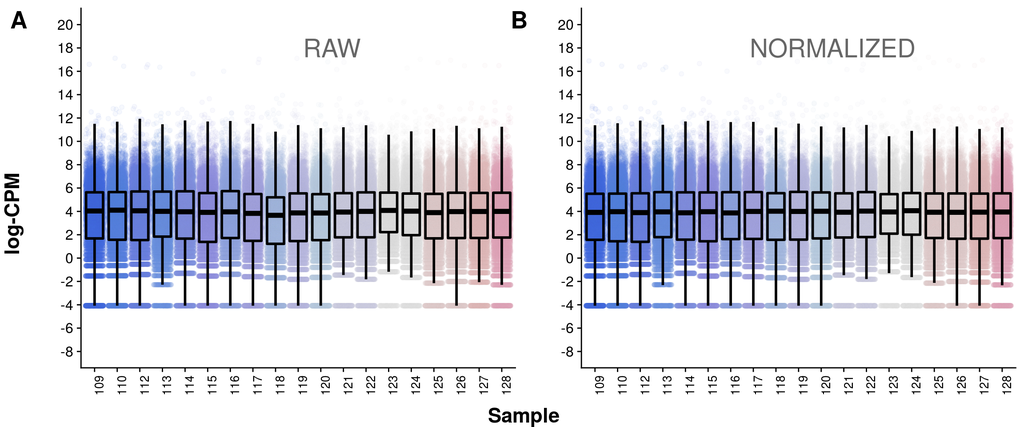

**Fig 2.** *Figure reports the distribution of gene expression (log-CPM) for each sample. Fig 2A reports the distribution prior to normalization while Fig 2B reports the distribution following normalization of library sizes using the TMM algorithm. Boxplots are based on all log-CPM values while points represent a random sample of 1e4 genes (due to processing time issues). The difference in the distribution of log-CPM using original and effective library sizes is minor but adjusted for.*

# 5 Dimensionality Reduction

**Fig 3. Variance explained by principal components based on the 500 genes with highest variance**

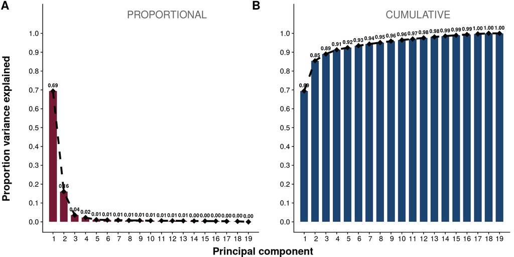

**Fig 3.** *Figure reports the proportion variance explained by each principal component. Fig 3A reports the proportional variance explained by each component while Fig 3B reports the cumulative variance explained by the components.*

**Table 2. Upper and lower bounds (bootstrapped 95 % confidence intervals) for the proportion of variance explained by principal component 1 to 10**

[output not shown]

**Fig 5. Dimensionality reduction using PCA and t-SNE of the 500 genes with highest variance**

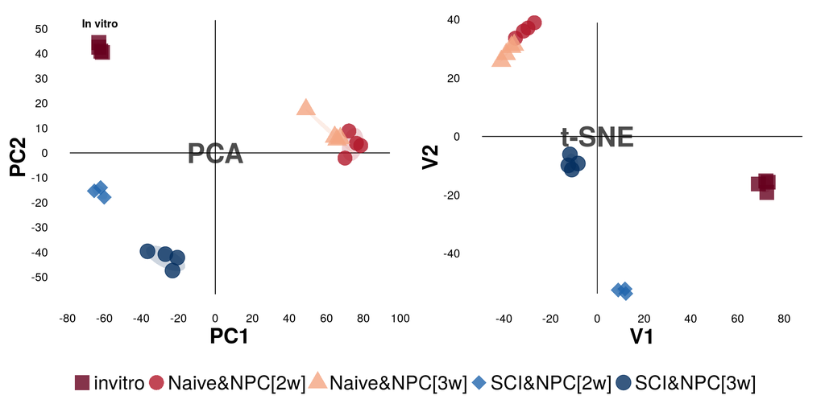

**Fig 5.** *Figure reports the samples in low dimensional space following dimensionality reduction with PCA and t-SNE for the 500 genes with the highest variance. Ellipses are added to the samples for easier recognition of the study groups.*

# 6 Clustering Algorithms

**Fig 9. Hierarchical clustering of samples using 500 most variable genes**

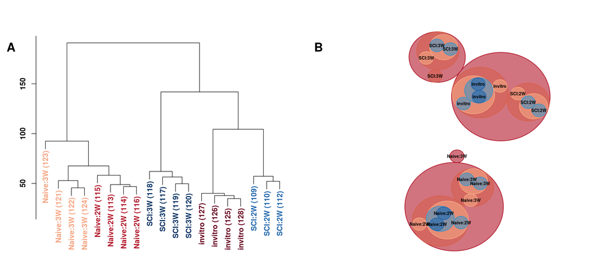

**Fig 9.** *Figure reports hierarchical clustering based on the 500 most variable genes. Fig 9A reports the clustering using a dendrogram while Fig 9B reports the same clustering using a circular packing plot.*

**Fig 10. Clustering of samples using common methods following dimensionality reduction with PCA and t-SNE**

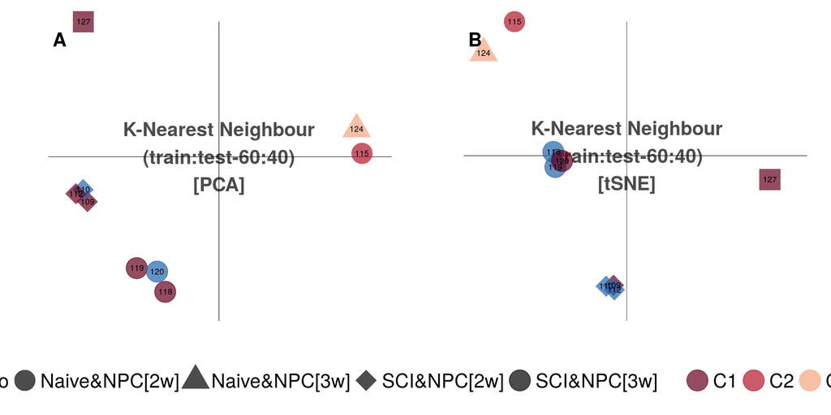

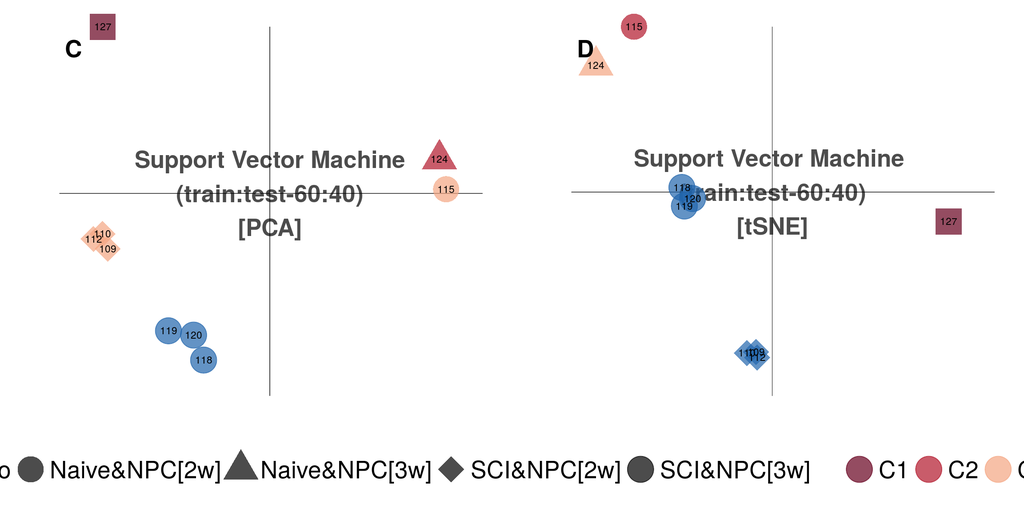

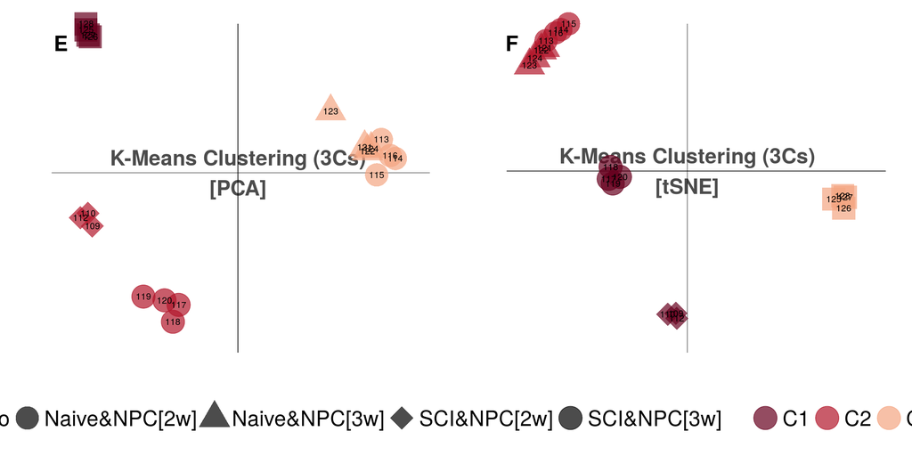

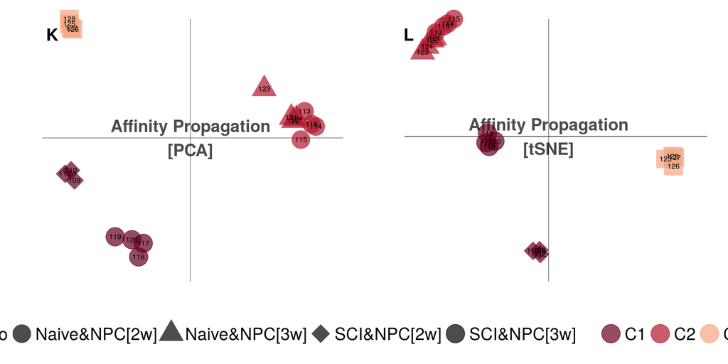